# Project: No-show appointments - [KaggleV2-May-2016]

- Introduction
- Data Wrangling
- Exploratory Data Analysis
- Conclusions

## Introduction

### Dataset Description

> **Tip**: In this section of the report, provide a brief introduction to the dataset you've selected/downloaded for analysis. Read through the description available on the homepage-links present [here](https://www.kaggle.com/joniarroba/noshowappointments). List all column names in each table, and their significance. In case of multiple tables, describe the relationship between tables.

#### Data Dictionary

01 - PatientId:Identification of a patient

02 - AppointmentID:Identification of each appointment

03 - Gender:Male or Female . Female is the greater proportion, woman takes way more care of they health in comparison to man.

04 - DataMarcacaoConsulta:The day of the actuall appointment, when they have to visit the doctor.

05 - DataAgendamento:The day someone called or registered the appointment, this is before appointment of course.

06 - Age:How old is the patient.

07 - Neighbourhood:Where the appointment takes place.

08 - Scholarship:True of False . Observation, this is a broad topic, consider reading this article https://en.wikipedia.org/wiki/Bolsa_Fam%C3%ADlia

09 - Hipertension:True or False

10 - Diabetes:True or False

Alcoholism:True or False

SMS_received:1 or more messages sent to the patient.

No-show:True or False.

```python
import numpy as np
import pandas as pd
import seaborn as sns
import matplotlib.pyplot as plt
%matplotlib inline
```

## Data Wrangling

> **Tip**: In this section of the report, you will load in the data, check for cleanliness, and then trim and clean your dataset for analysis. Make sure that you **document your data cleaning steps in mark-down cells precisely and justify your cleaning decisions.**

Data Wrangling which include : 1.Gathering Data 2.Assessing Data 3.cleaning Data

### Gathering Data

```python
# Load your data and print out a few lines. Perform operations to inspect data
#   types and look for instances of missing or possibly errant data.
df = pd.read_csv('KaggleV2-May-2016.csv')
```

we aqucistion data from dataset like : csv file in our example

```python
df.head()
```

|  | PatientId | AppointmentID | Gender | ScheduledDay | AppointmentDay | Age | Neighbourhood | Scholarship | Hipertension | Diabetes | Alcoholism | Handcap | SMS_received | Noshow |
| --- | --- | --- | --- | --- | --- | --- | --- | --- | --- | --- | --- | --- | --- | --- |
| 0 | 2.990000e+13 | 5642903 | F | 2016-04-29 18:38:08+00:00 | 2016-04-29 00:00:00+00:00 | 62 | JARDIM DA PENHA | 0 | 1 | 0 | 0 | 0 | 0 | No |
| 1 | 5.590000e+14 | 5642503 | M | 2016-04-29 16:08:27+00:00 | 2016-04-29 00:00:00+00:00 | 56 | JARDIM DA PENHA | 0 | 0 | 0 | 0 | 0 | 0 | No |
| 2 | 4.260000e+12 | 5642549 | F | 2016-04-29 16:19:04+00:00 | 2016-04-29 00:00:00+00:00 | 62 | MATA DA PRAIA | 0 | 0 | 0 | 0 | 0 | 0 | No |
| 3 | 8.680000e+11 | 5642828 | F | 2016-04-29 17:29:31+00:00 | 2016-04-29 00:00:00+00:00 | 8 | PONTAL DE CAMBURI | 0 | 0 | 0 | 0 | 0 | 0 | No |
| 4 | 8.840000e+12 | 5642494 | F | 2016-04-29 16:07:23+00:00 | 2016-04-29 00:00:00+00:00 | 56 | JARDIM DA PENHA | 0 | 1 | 1 | 0 | 0 | 0 | No |

we use head() or tail() function to display a sample of data

```python
df.tail()
```

|  | PatientId | AppointmentID | Gender | ScheduledDay | AppointmentDay | Age | Neighbourhood | Scholarship | Hipertension | Diabetes | Alcoholism | Handcap | SMS_received | Noshow |
| --- | --- | --- | --- | --- | --- | --- | --- | --- | --- | --- | --- | --- | --- | --- |
| 110522 | 2.570000e+12 | 5651768 | F | 2016-05-03 09:15:35+00:00 | 2016-06-07 00:00:00+00:00 | 56 | MARIA ORTIZ | 0 | 0 | 0 | 0 | 0 | 1 | No |
| 110523 | 3.600000e+12 | 5650093 | F | 2016-05-03 07:27:33+00:00 | 2016-06-07 00:00:00+00:00 | 51 | MARIA ORTIZ | 0 | 0 | 0 | 0 | 0 | 1 | No |
| 110524 | 1.560000e+13 | 5630692 | F | 2016-04-27 16:03:52+00:00 | 2016-06-07 00:00:00+00:00 | 21 | MARIA ORTIZ | 0 | 0 | 0 | 0 | 0 | 1 | No |
| 110525 | 9.210000e+13 | 5630323 | F | 2016-04-27 15:09:23+00:00 | 2016-06-07 00:00:00+00:00 | 38 | MARIA ORTIZ | 0 | 0 | 0 | 0 | 0 | 1 | No |
| 110526 | 3.780000e+14 | 5629448 | F | 2016-04-27 13:30:56+00:00 | 2016-06-07 00:00:00+00:00 | 54 | MARIA ORTIZ | 0 | 0 | 0 | 0 | 0 | 1 | No |

### Assessing Data

We assessing our data using some function like : shape , ndim , dtypes , size , info() , nunique() , isnull()

```python
# return number of columns and number of row
df.shape
```

```
(110527, 14)
```

the shape function get number of rows and number of columns in tuple

```python
#return number of dimensions of data
df.ndim
```

```
2
```

```python
#return types of each column
df.dtypes
```

```
PatientId         float64
AppointmentID       int64
Gender             object
ScheduledDay       object
AppointmentDay     object
Age                 int64
Neighbourhood      object
Scholarship         int64
Hipertension        int64
Diabetes            int64
Alcoholism          int64
Handcap             int64
SMS_received        int64
Noshow             object
dtype: object
```

dtypes show us data type of each column (features)

```python
# return size of Dataset which is a multiplication of number of rows and number of columns
df.size
```

```
1547378
```

size function show us the result of multiplication of number of rows and number of columns

```python
#return number of non-null-value and datatype of each column
df.info()
```

```
<class 'pandas.core.frame.DataFrame'>
RangeIndex: 110527 entries, 0 to 110526
Data columns (total 14 columns):
PatientId         110527 non-null float64
AppointmentID     110527 non-null int64
Gender            110527 non-null object
ScheduledDay      110527 non-null object
AppointmentDay    110527 non-null object
Age               110527 non-null int64
Neighbourhood     110527 non-null object
Scholarship       110527 non-null int64
Hipertension      110527 non-null int64
Diabetes          110527 non-null int64
Alcoholism        110527 non-null int64
Handcap           110527 non-null int64
SMS_received      110527 non-null int64
Noshow            110527 non-null object
dtypes: float64(1), int64(8), object(5)
memory usage: 11.8+ MB
```

info() function show us number of non_null_value in each column and datatype

it has two features(no of non_null_value,datatype)

```python
#return number of unique value
df.nunique()
```

```
PatientId           6100
AppointmentID     110527
Gender                 2
ScheduledDay      103549
AppointmentDay        27
Age                  104
Neighbourhood         81
Scholarship            2
Hipertension           2
Diabetes               2
Alcoholism             2
Handcap                5
SMS_received           2
Noshow                 2
dtype: int64
```

nunique() show us number of unique values in each column

```python
# return which value is nul or not for each element in DataSet
df.isnull()
```

[output not shown]

110527 rows × 14 columns

isnull() function show us boolean value for each element (each cell) it is null or not

if it(element) null return True

else return False

```python
# return which value is nul or not for each columns in DataSet
df.isnull().any()
```

```
PatientId         False
AppointmentID     False
Gender            False
ScheduledDay      False
AppointmentDay    False
Age               False
Neighbourhood     False
Scholarship       False
Hipertension      False
Diabetes          False
Alcoholism        False
Handcap           False
SMS_received      False
Noshow            False
dtype: bool
```

isnull().any() function show us boolean value for each column it is null or not

if column null return True

else return False

```python
#return number of columns has a null value
df.isnull().any().sum()
```

```
0
```

```python
#return number of null value for each column
df.isnull().sum()
```

```
PatientId         0
AppointmentID     0
Gender            0
ScheduledDay      0
AppointmentDay    0
Age               0
Neighbourhood     0
Scholarship       0
Hipertension      0
Diabetes          0
Alcoholism        0
Handcap           0
SMS_received      0
Noshow            0
dtype: int64
```

if column null return 1

else return 0

```python
#return a number of cell has a null value
df.isnull().sum().sum()
```

```
0
```

```python
#return statistical descriptive of dataset for each column
df.describe()
```

|  | PatientId | AppointmentID | Age | Scholarship | Hipertension | Diabetes | Alcoholism | Handcap | SMS_received |
| --- | --- | --- | --- | --- | --- | --- | --- | --- | --- |
| count | 1.105270e+05 | 1.105270e+05 | 110527.000000 | 110527.000000 | 110527.000000 | 110527.000000 | 110527.000000 | 110527.000000 | 110527.000000 |
| mean | 1.474961e+14 | 5.675305e+06 | 37.088874 | 0.098266 | 0.197246 | 0.071865 | 0.030400 | 0.022248 | 0.321026 |
| std | 2.560943e+14 | 7.129575e+04 | 23.110205 | 0.297675 | 0.397921 | 0.258265 | 0.171686 | 0.161543 | 0.466873 |
| min | 3.920000e+04 | 5.030230e+06 | -1.000000 | 0.000000 | 0.000000 | 0.000000 | 0.000000 | 0.000000 | 0.000000 |
| 25% | 4.170000e+12 | 5.640286e+06 | 18.000000 | 0.000000 | 0.000000 | 0.000000 | 0.000000 | 0.000000 | 0.000000 |
| 50% | 3.170000e+13 | 5.680573e+06 | 37.000000 | 0.000000 | 0.000000 | 0.000000 | 0.000000 | 0.000000 | 0.000000 |
| 75% | 9.440000e+13 | 5.725524e+06 | 55.000000 | 0.000000 | 0.000000 | 0.000000 | 0.000000 | 0.000000 | 1.000000 |
| max | 1.000000e+15 | 5.790484e+06 | 115.000000 | 1.000000 | 1.000000 | 1.000000 | 1.000000 | 4.000000 | 1.000000 |

describe() function show us descriptive statistical value for each column

in 8 value such as: count element in each column

```
                mean : getting average in each column

                std : standarded deviation

                min : minimum value in each column

                max : maximum value in each column

                50% : median of value for each column
```

### Data Cleaning

> **Tip**: Make sure that you keep your reader informed on the steps that you are taking in your investigation. Follow every code cell, or every set of related code cells, with a markdown cell to describe to the reader what was found in the preceding cell(s). Try to make it so that the reader can then understand what they will be seeing in the following cell(s).

1.duplicated data

2.missing value

3.incorrect datatype

from assessing no NULL value

we will check for missing value and incorrect datatype

```python
df.drop(['PatientId','AppointmentID'],axis=1,inplace = True)
```

```python
df.head(1)
```

|  | Gender | ScheduledDay | AppointmentDay | Age | Neighbourhood | Scholarship | Hipertension | Diabetes | Alcoholism | Handcap | SMS_received | Noshow |
| --- | --- | --- | --- | --- | --- | --- | --- | --- | --- | --- | --- | --- |
| 0 | F | 2016-04-29 18:38:08+00:00 | 2016-04-29 00:00:00+00:00 | 62 | JARDIM DA PENHA | 0 | 1 | 0 | 0 | 0 | 0 | No |

```python
df.dtypes
```

```
Gender            object
ScheduledDay      object
AppointmentDay    object
Age                int64
Neighbourhood     object
Scholarship        int64
Hipertension       int64
Diabetes           int64
Alcoholism         int64
Handcap            int64
SMS_received       int64
Noshow            object
dtype: object
```

After discussing the structure of the data and any problems that need to be

cleaned, perform those cleaning steps in the second part of this section.

#### duplicicated data

```python
#check for duplicated data
sum(df.duplicated())
```

```
635
```

```python
# if we have duplicated data we remove it
df.drop_duplicates(inplace = True)
```

```python
sum(df.duplicated())
```

```
0
```

##### incorrect datatype

```python
df['ScheduledDay'] = pd.to_datetime(df['ScheduledDay'])
```

```python
df['AppointmentDay'] = pd.to_datetime(df['AppointmentDay'])
```

### checking

```python
df.dtypes
```

```
Gender                         object
ScheduledDay      datetime64[ns, UTC]
AppointmentDay    datetime64[ns, UTC]
Age                             int64
Neighbourhood                  object
Scholarship                     int64
Hipertension                    int64
Diabetes                        int64
Alcoholism                      int64
Handcap                         int64
SMS_received                    int64
Noshow                         object
dtype: object
```

```python
df.Noshow.count()
```

```
109892
```

```python
df.Noshow.value_counts()
```

```
No     87794
Yes    22098
Name: Noshow, dtype: int64
```

```python
df.Neighbourhood.value_counts()
```

```
JARDIM CAMBURI                 7616
MARIA ORTIZ                    5804
RESISTÊNCIA                    4387
JARDIM DA PENHA                3873
ITARARÉ                        3470
                               ...
ILHA DO BOI                      35
ILHA DO FRADE                    10
AEROPORTO                         8
ILHAS OCEÂNICAS DE TRINDADE       2
PARQUE INDUSTRIAL                 1
Name: Neighbourhood, Length: 81, dtype: int64
```

```python
df.head(1)
```

|  | Gender | ScheduledDay | AppointmentDay | Age | Neighbourhood | Scholarship | Hipertension | Diabetes | Alcoholism | Handcap | SMS_received | Noshow |
| --- | --- | --- | --- | --- | --- | --- | --- | --- | --- | --- | --- | --- |
| 0 | F | 2016-04-29 18:38:08+00:00 | 2016-04-29 00:00:00+00:00 | 62 | JARDIM DA PENHA | 0 | 1 | 0 | 0 | 0 | 0 | No |

#### non_dublicated data....non_missing value....non incorrect datatype

## Exploratory Data Analysis

> **Tip**: Now that you've trimmed and cleaned your data, you're ready to move on to exploration. **Compute statistics** and **create visualizations** with the goal of addressing the research questions that you posed in the Introduction section. You should compute the relevant statistics throughout the analysis when an inference is made about the data. Note that at least two or more kinds of plots should be created as part of the exploration, and you must compare and show trends in the varied visualizations.

> **Tip**: - Investigate the stated question(s) from multiple angles. It is recommended that you be systematic with your approach. Look at one variable at a time, and then follow it up by looking at relationships between variables. You should explore at least three variables in relation to the primary question. This can be an exploratory relationship between three variables of interest, or looking at how two independent variables relate to a single dependent variable of interest. Lastly, you should perform both single-variable (1d) and multiple-variable (2d) explorations.

### Research Question 1 (What factors are important for us to know in order to predict if a patient will show up for their scheduled appointment? Exploraty Data Analysis

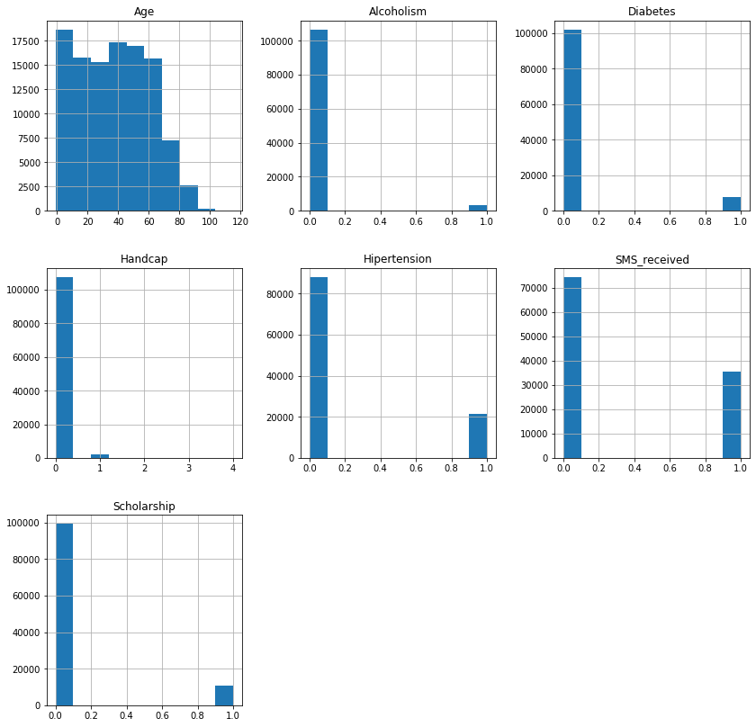

```python
# Use this, and more code cells, to explore your data. Don't forget to add
#   Markdown cells to document your observations and findings.
df.hist(figsize = (14,14));
```

using hist() function to draw Histogram for each column

and use figsize(,) parameter to show it obviously

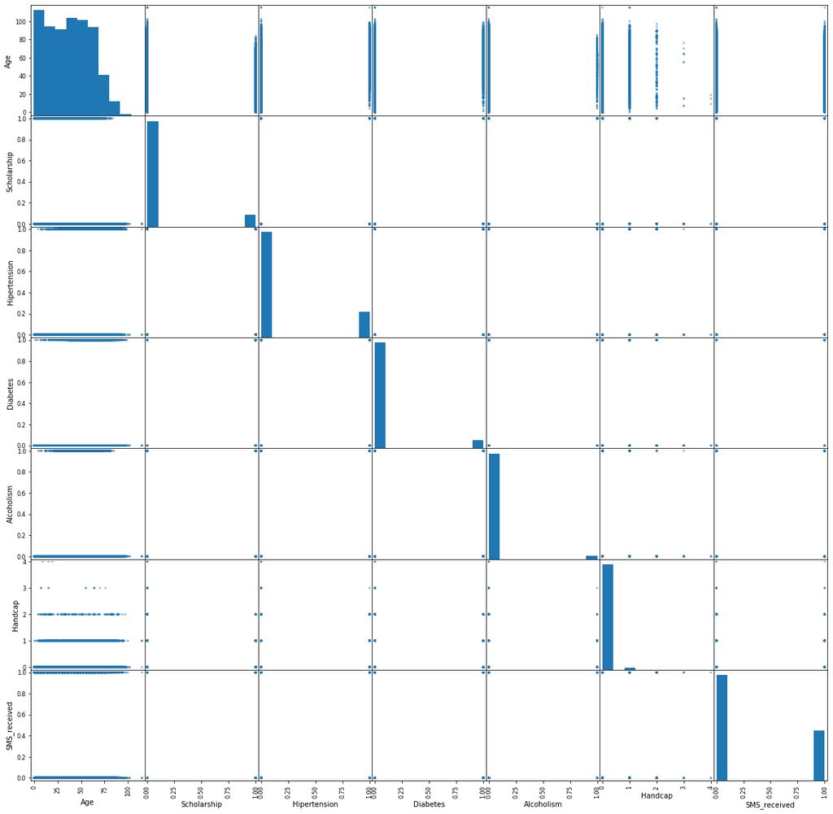

```python
pd.plotting.scatter_matrix(df, figsize = (20,20));
```

using plotting.scatter_matrix() function to draw Histogramsfor each column

and scatter plotting between numerical columns

and use figsize(,) parameter to show it obviously

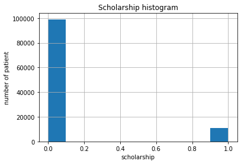

```python
df.Scholarship.hist();
plt.ylabel('number of patient')
plt.xlabel('scholarship')
plt.title('Scholarship histogram');
```

Histogram for scholarship of patients

```python
df.Scholarship.count()
```

```
109892
```

count() function to get number of element in column scholarship

```python
df.Scholarship.sum()
```

```
10801
```

sum() function to get summation of element in column scholarship

```python
df.Scholarship.describe()
```

```
count    109892.000000
mean          0.098287
std           0.297704
min           0.000000
25%           0.000000
50%           0.000000
75%           0.000000
max           1.000000
Name: Scholarship, dtype: float64
```

describe() function to get descriptive statistical of element in column scholarship

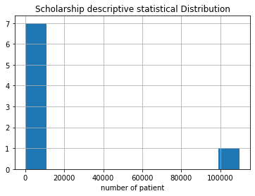

```python
df.Scholarship.describe().hist();
plt.xlabel('number of patient')
plt.title('Scholarship descriptive statistical Distribution');
```

Histogram for describe() function to get descriptive statistical of element in column scholarship

```python
df.Scholarship.value_counts()
```

```
0    99091
1    10801
Name: Scholarship, dtype: int64
```

value_counts() function to get number repeation of each element in column scholarship

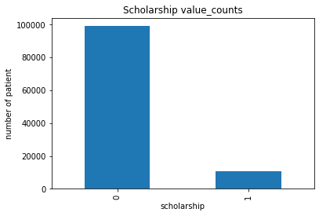

```python
df.Scholarship.value_counts().plot(kind='bar');
plt.ylabel('number of patient')
plt.xlabel('scholarship')
plt.title('Scholarship value_counts');
```

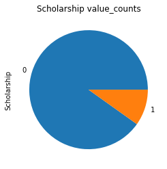

```python
df.Scholarship.value_counts().plot(kind='pie');

plt.title('Scholarship value_counts');
```

Histogram for Age of patients

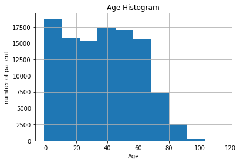

```python
df.Age.hist();
plt.ylabel('number of patient')
plt.xlabel('Age')
plt.title('Age Histogram');
```

```python
df.Age.count()
```

```
109892
```

count() function to get number of element in column Age

```python
df.Age.describe()
```

```
count    109892.000000
mean         37.089506
std          23.121196
min          -1.000000
25%          18.000000
50%          37.000000
75%          55.000000
max         115.000000
Name: Age, dtype: float64
```

describe() function to get descriptive statistical of element in column Age

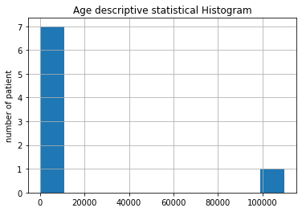

```python
df.Age.describe().hist();
plt.ylabel('number of patient')
plt.title('Age descriptive statistical Histogram');
```

Histogram for describe() function to get descriptive statistical of element in column Age

```python
df.Age.value_counts()
```

```
 0      3530
 1      2271
 52     1738
 49     1645
 53     1641
        ...
 115       4
 100       3
 102       2
 99        1
-1         1
Name: Age, Length: 104, dtype: int64
```

value_counts() function to get number repeation of each element in column Age

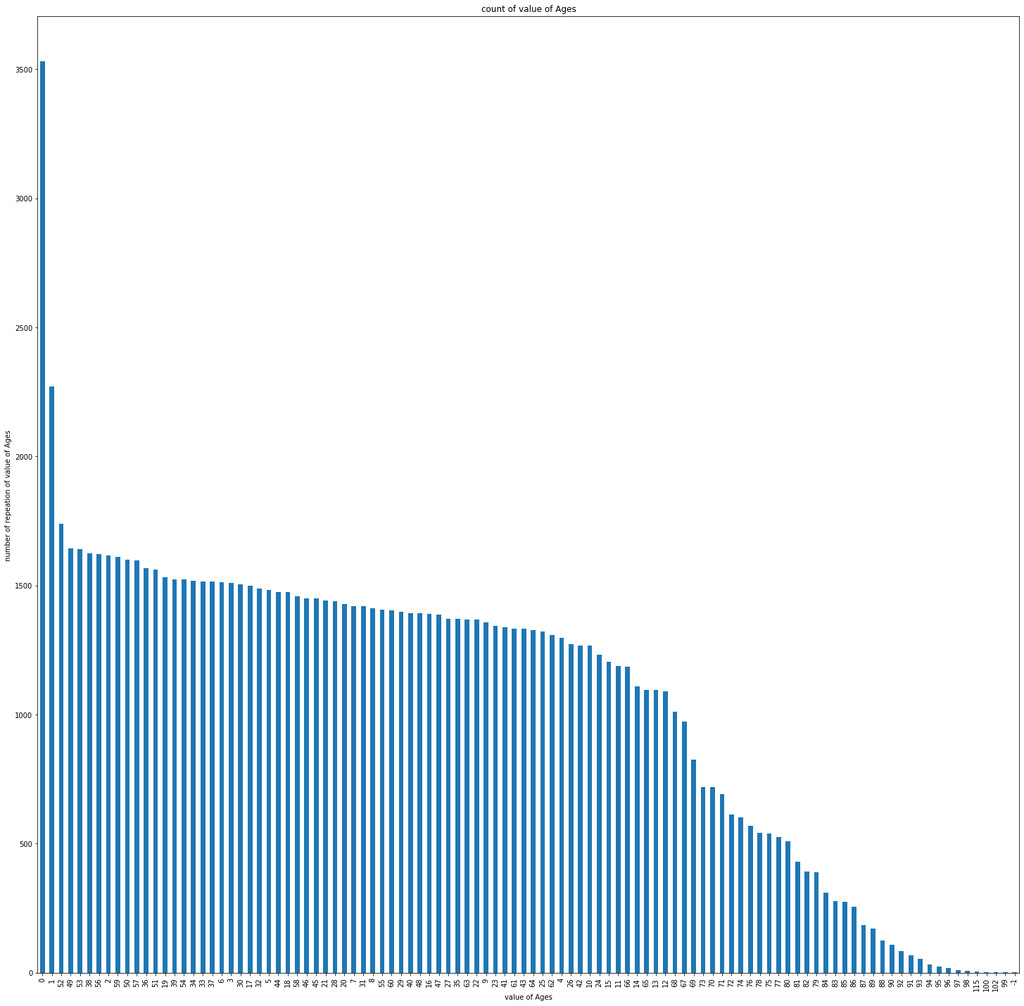

```python
df.Age.value_counts().plot(kind='bar',figsize=(25,25));
plt.ylabel('number of repeation of value of Ages ')
plt.xlabel('value of Ages')
plt.title('count of value of Ages');
```

```python
df.Age.sum()
```

```
4075840
```

```python
df.Age.mean()
```

```
37.08950606049576
```

mean() function to get average of element in column Age

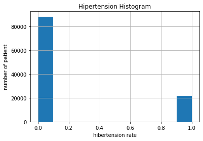

```python
df.Hipertension.hist();
plt.ylabel('number of patient')
plt.xlabel('hibertension rate')
plt.title('Hipertension Histogram');
```

Histogram for hipertension of patients

```python
df.Hipertension.count()
```

```
109892
```

count() function to get number of element in column hipertension

```python
df.Hipertension.describe()
```

```
count    109892.000000
mean          0.197248
std           0.397923
min           0.000000
25%           0.000000
50%           0.000000
75%           0.000000
max           1.000000
Name: Hipertension, dtype: float64
```

describe() function to get descriptive statistical of element in column hipertension

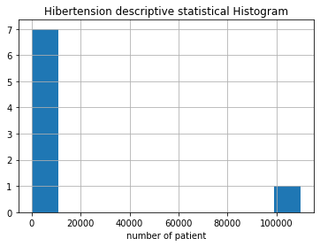

```python
df.Hipertension.describe().hist();
plt.xlabel('number of patient')
plt.title('Hibertension descriptive statistical Histogram');
```

describe() function to get descriptive statistical of element in column hipertension

```python
df.Hipertension.value_counts()
```

```
0    88216
1    21676
Name: Hipertension, dtype: int64
```

value_counts() function to get number repeation of each element in column hipertension

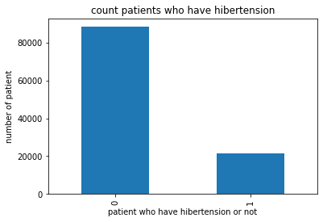

```python
df.Hipertension.value_counts().plot(kind='bar');
plt.ylabel('number of patient')
plt.xlabel('patient who have hibertension or not')
plt.title('count patients who have hibertension');
```

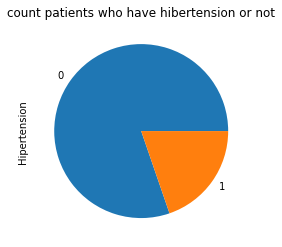

```python
df.Hipertension.value_counts().plot(kind='pie');
plt.title('count patients who have hibertension or not');
```

```python
df.Hipertension.sum()
```

```
21676
```

sum() function to get summation of element in column hipertension

```python
df.Hipertension.mean()
```

```
0.1972482073308339
```

mean() function to get average of element in column hipertension

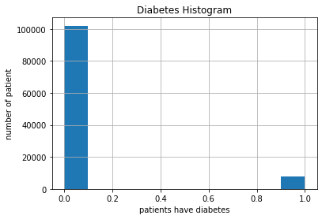

```python
df.Diabetes.hist();
plt.ylabel('number of patient')
plt.xlabel('patients have diabetes')
plt.title('Diabetes Histogram');
```

Histogram for diabetes of patients

```python
df.Diabetes.count()
```

```
109892
```

count() function to get number of element in column Diabetes

```python
df.Diabetes.value_counts()
```

```
0    101999
1      7893
Name: Diabetes, dtype: int64
```

value_counts() function to get number repeation of each element in column Diabetes

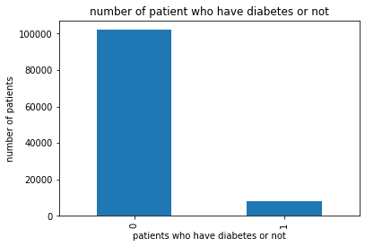

```python
df.Diabetes.value_counts().plot(kind='bar');
plt.ylabel('number of patients')
plt.xlabel('patients who have diabetes or not')
plt.title('number of patient who have diabetes or not');
```

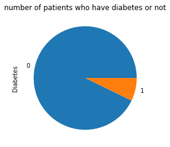

```python
df.Diabetes.value_counts().plot(kind='pie');
plt.title('number of patients who have diabetes or not');
```

```python
df.Diabetes.sum()
```

```
7893
```

sum() function to get summation of element in column Diabetes

```python
df.Diabetes.mean()
```

```
0.07182506460888873
```

mean() function to get average of element in column Diabetes

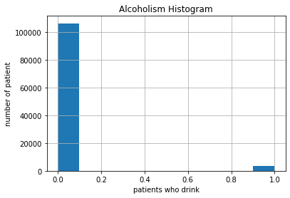

```python
df.Alcoholism.hist();
plt.ylabel('number of patient')
plt.xlabel('patients who drink')
plt.title('Alcoholism Histogram');
```

Histogram for Alcoholism of patients

```python
df.Alcoholism.count()
```

```
109892
```

count() function to get number of element in column Alcoholism

```python
df.Alcoholism.value_counts()
```

```
0    106548
1      3344
Name: Alcoholism, dtype: int64
```

value_counts() function to get number repeation of each element in column Alcoholism

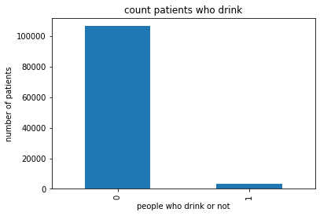

```python
df.Alcoholism.value_counts().plot(kind='bar');
plt.ylabel('number of patients')
plt.xlabel('people who drink or not')
plt.title('count patients who drink');
```

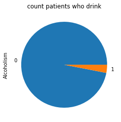

```python
df.Alcoholism.value_counts().plot(kind='pie');
plt.title('count patients who drink');
```

```python
df.Alcoholism.sum()
```

```
3344
```

sum() function to get summation of element in column Alcohloism

```python
df.Alcoholism.mean()
```

```
0.030429876606122376
```

mean() function to get average of element in column Alcoholism

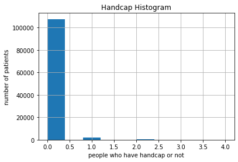

```python
df.Handcap.hist();
plt.ylabel('number of patients')
plt.xlabel('people who have handcap or not')
plt.title('Handcap Histogram');
```

Histogram for Handcap of patients

```python
df.Handcap.count()
```

```
109892
```

count() function to get number of element in column Handcap

```python
df.Handcap.value_counts()
```

```
0    107673
1      2023
2       182
3        11
4         3
Name: Handcap, dtype: int64
```

value_counts() function to get number repeation of each element in column Handcap

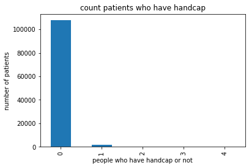

```python
df.Handcap.value_counts().plot(kind='bar');
plt.ylabel('number of patients')
plt.xlabel('people who have handcap or not')
plt.title('count patients who have handcap');
```

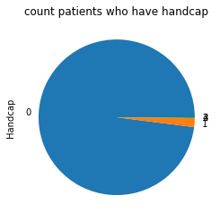

```python
df.Handcap.value_counts().plot(kind='pie');
plt.title('count patients who have handcap');
```

```python
df.Handcap.sum()
```

```
2432
```

sum() function to get summation of element in column Handcap

```python
df.Handcap.mean()
```

```
0.022130819349907183
```

mean() function to get average of element in column Handcap

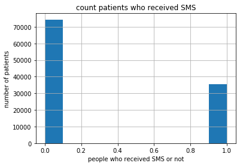

```python
df.SMS_received.hist();
plt.ylabel('number of patients')
plt.xlabel('people who received SMS or not')
plt.title('count patients who received SMS');
```

Histogram for SMS_received to patients

```python
df.SMS_received.count()
```

```
109892
```

count() function to get number of element in column SMS_received

```python
df.SMS_received.value_counts()
```

```
0    74410
1    35482
Name: SMS_received, dtype: int64
```

value_counts() function to get number repeation of each element in column SMS_received

```python
df.SMS_received.sum()
```

```
35482
```

sum() function to get summation of element in column SMS_recieved

```python
df.SMS_received.mean()
```

```
0.322880646452881
```

mean() function to get average of element in column SMS_recevied

```python
df.groupby(['Noshow'])['Hipertension','Alcoholism','Handcap','Diabetes','Scholarship'].mean()
```

| Noshow | Hipertension | Alcoholism | Handcap | Diabetes | Scholarship |
| --- | --- | --- | --- | --- | --- |
| No | 0.204433 | 0.030480 | 0.022633 | 0.073707 | 0.093913 |
| Yes | 0.168703 | 0.030229 | 0.020138 | 0.064350 | 0.115667 |

average people who come or not with any diesase like : ['Hipertension','Alcoholism','Handcap','Diabetes','Scholarship']

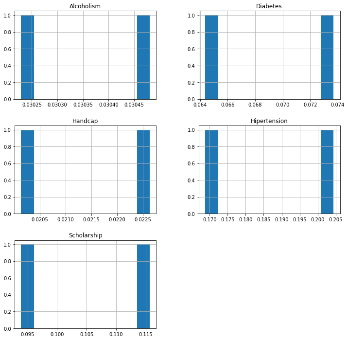

```python
df.groupby(['Noshow'])['Hipertension','Alcoholism','Handcap','Diabetes','Scholarship'].mean().hist(figsize=(12,12));
```

Histgram of average people who come or not with any diesase like : ['Hipertension','Alcoholism','Handcap','Diabetes','Scholarship']

```python
df.groupby(['Noshow'])['Hipertension','Alcoholism','Handcap','Diabetes','Scholarship'].count()
```

| Noshow | Hipertension | Alcoholism | Handcap | Diabetes | Scholarship |
| --- | --- | --- | --- | --- | --- |
| No | 87794 | 87794 | 87794 | 87794 | 87794 |
| Yes | 22098 | 22098 | 22098 | 22098 | 22098 |

number of people who come or not with any diesase like : ['Hipertension','Alcoholism','Handcap','Diabetes','Scholarship']

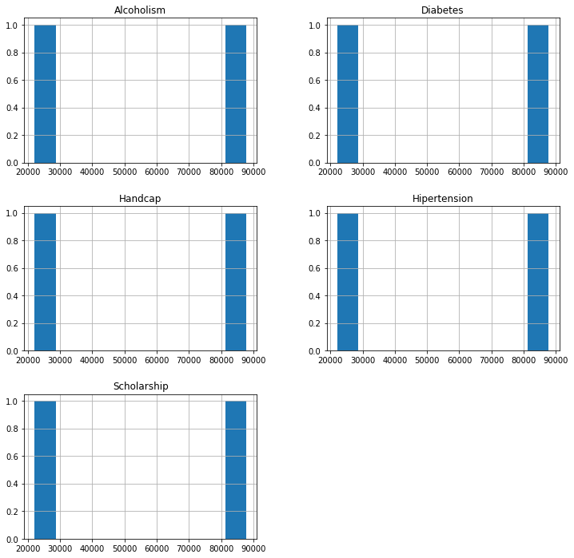

```python
df.groupby(['Noshow'])['Hipertension','Alcoholism','Handcap','Diabetes','Scholarship'].count().hist(figsize=(12,12));
```

Histgram of number of people who come or not with any diesase like : ['Hipertension','Alcoholism','Handcap','Diabetes','Scholarship']

```python
df.groupby(['Noshow'])['Hipertension','Alcoholism','Handcap','Diabetes','Scholarship'].sum()
```

| Noshow | Hipertension | Alcoholism | Handcap | Diabetes | Scholarship |
| --- | --- | --- | --- | --- | --- |
| No | 17948 | 2676 | 1987 | 6471 | 8245 |
| Yes | 3728 | 668 | 445 | 1422 | 2556 |

summation of number of people who come or not with any diesase like : ['Hipertension','Alcoholism','Handcap','Diabetes','Scholarship']

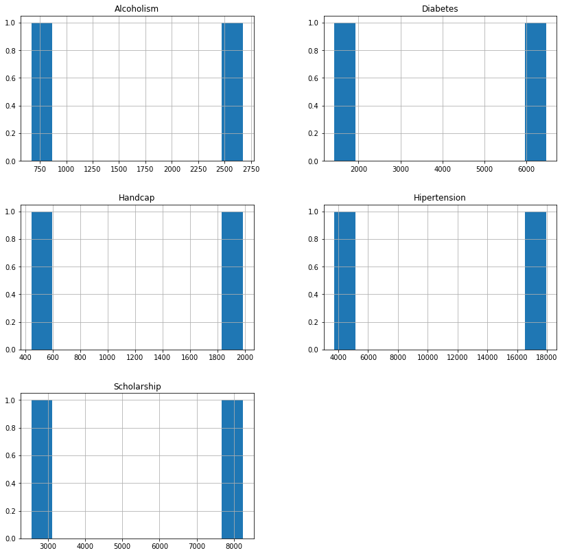

```python
df.groupby(['Noshow'])['Hipertension','Alcoholism','Handcap','Diabetes','Scholarship'].sum().hist(figsize=(14,14));
```

Histgram of summation of number of people who come or not with any diesase like : ['Hipertension','Alcoholism','Handcap','Diabetes','Scholarship']

```python
df.groupby(['Scholarship'])['Hipertension','Alcoholism','Handcap','Diabetes'].mean()
```

| Scholarship | Hipertension | Alcoholism | Handcap | Diabetes |
| --- | --- | --- | --- | --- |
| 0 | 0.199837 | 0.028479 | 0.022605 | 0.073942 |
| 1 | 0.173502 | 0.048329 | 0.017776 | 0.052403 |

average people who have scholarship or not with any diesase like : ['Hipertension','Alcoholism','Handcap','Diabetes','Scholarship']

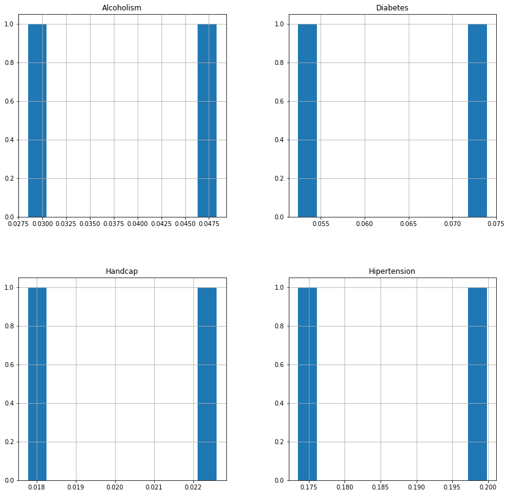

```python
df.groupby(['Scholarship'])['Hipertension','Alcoholism','Handcap','Diabetes'].mean().hist(figsize=(14,14));
```

Histgram of average people who have scholarship or not with any diesase like : ['Hipertension','Alcoholism','Handcap','Diabetes','Scholarship']

```python
df.groupby(['Scholarship'])['Hipertension','Alcoholism','Handcap','Diabetes'].sum()
```

| Scholarship | Hipertension | Alcoholism | Handcap | Diabetes |
| --- | --- | --- | --- | --- |
| 0 | 19802 | 2822 | 2240 | 7327 |
| 1 | 1874 | 522 | 192 | 566 |

summation people who have scholarship or not with any diesase like : ['Hipertension','Alcoholism','Handcap','Diabetes','Scholarship']